# L15Ex_JetTurbine_Rick_Davila

Rick Davila

6/05/2020

#### Perform data housekeeping - upload, name columns, display to make sure it reads properly, etc.

```r
knitr::opts_chunk$set(echo = TRUE)

#Sys.setenv(JAVA_HOME='C:\\Program Files\\Java\\jdk-14.0.1') # for 64-bit version
#library(rJava)

library("xlsx") # Needed to read data
library(MuMIn)
library(MASS)   # Needed for ginv() function


jt_data <- read.xlsx("data-table-B13.xlsx", sheetIndex = 1, sheetName=NULL, rowIndex=NULL, startRow=NULL, endRow=NULL, colIndex= NULL, as.data.frame=TRUE, header=TRUE, colClasses=NA, keepFormulas=FALSE, encoding="unknown")

# Give labels to data columns
names(jt_data) <- c("thrust", "primary", "secondary", "fuel", "press", "exhaust", "ambient")
attach(jt_data)

# Output data to make sure it reads properly
jt_data # Note: On the spreadsheet provided on the course website, Observation #7 is 580 but in Table 8.1 and subsequent textbook results tables it is 680.
```

| thrust | primary | secondary | fuel | press | exhaust | ambient |
| --- | --- | --- | --- | --- | --- | --- |
| 4540 | 2140 | 20640 | 30250 | 205 | 1732 | 99 |
| 4315 | 2016 | 20280 | 30010 | 195 | 1697 | 100 |
| 4095 | 1905 | 19860 | 29780 | 184 | 1662 | 97 |
| 3650 | 1675 | 18980 | 29330 | 164 | 1598 | 97 |
| 3200 | 1474 | 18100 | 28960 | 144 | 1541 | 97 |
| 4833 | 2239 | 20740 | 30083 | 216 | 1709 | 87 |
| 4617 | 2120 | 20305 | 29831 | 206 | 1669 | 87 |
| 4340 | 1990 | 19961 | 29604 | 196 | 1640 | 87 |
| 3820 | 1702 | 18916 | 29088 | 171 | 1572 | 85 |
| 3368 | 1487 | 18012 | 28675 | 149 | 1522 | 85 |

[output cut: 30 more lines]

```r
# Output data structure and dimensions
str(jt_data)
```

```
## 'data.frame':    40 obs. of  7 variables:
##  $ thrust   : num  4540 4315 4095 3650 3200 ...
##  $ primary  : num  2140 2016 1905 1675 1474 ...
##  $ secondary: num  20640 20280 19860 18980 18100 ...
##  $ fuel     : num  30250 30010 29780 29330 28960 ...
##  $ press    : num  205 195 184 164 144 216 206 196 171 149 ...
##  $ exhaust  : num  1732 1697 1662 1598 1541 ...
##  $ ambient  : num  99 100 97 97 97 87 87 87 85 85 ...
```

```r
dim(jt_data)
```

```
## [1] 40  7
```

```r
jt_lm <- lm(thrust~primary+secondary+fuel+press+exhaust+ambient, data=jt_data, na.action = "na.fail") # Linear model of raw data

# Use dredge() function to automatically perform all regressors regression
combinations <- dredge(jt_lm, extra = c(R_Sq = function(x) summary(x)$r.squared,R_Sq_Adj = function(x) summary(x)$adj.r.squared, MS_Res = function(x) summary(x)$sigma^2,Cp, MallowCp = function(x) summary(x)$sigma^2*df.residual(x)/summary(jt_lm)$sigma^2-dim(jt_data)[1]+2*length(x$coefficients)))
```

```
## Fixed term is "(Intercept)"
```

```r
print(combinations)
```

```
## Global model call: lm(formula = thrust ~ primary + secondary + fuel + press + exhaust +
##     ambient, data = jt_data, na.action = "na.fail")
## ---
## Model selection table
##      (Intrc)    ambnt    exhst     fuel     press  prmry     scndr    R_Sq
## 24  -4280.00 -17.5100  0.64670  0.20980           1.4420           0.99750
## 32  -3982.00 -16.2800  0.83430  0.18430  3.746000 1.0960           0.99760
## 28     37.62 -12.9900  1.26000           4.608000 1.2410           0.99740
## 22  -7018.00 -17.8400           0.34430           1.3630           0.99720
## 20    366.80 -13.9800  1.09700                    1.7060           0.99720
## 56  -4976.00 -18.1500  0.63070  0.25270           1.4710 -0.027500 0.99750
## 64  -4738.00 -16.9500  0.82190  0.23060  3.850000 1.1190 -0.030180 0.99770
## 54  -7763.00 -18.5900           0.39120           1.4000 -0.032610 0.99730
## 30  -7190.00 -17.4500           0.34900  1.296000 1.2360           0.99720
## 60    -21.22 -13.0300  1.23800           4.534000 1.2280  0.006968 0.99740
```

[output cut: 120 more lines]

```r
# Note - the book calculates Cp very differently than R does. The "Cp" column is done automatically through R and the 'MallowCp' column calculates it manually using the formula in the book.

# Reproduce the analysis for the candidate models in the video.
```

#### Influence analysis from the full model

```r
# full model lm()
model <- lm(thrust~primary+secondary+fuel+press+exhaust+ambient)
summary(model)
```

```
##
## Call:
## lm(formula = thrust ~ primary + secondary + fuel + press + exhaust +
##     ambient)
##
## Residuals:
##     Min      1Q  Median      3Q     Max
## -49.949 -19.028  -1.572  17.139  49.606
##
## Coefficients:
##               Estimate Std. Error t value Pr(>|t|)
## (Intercept) -4.738e+03  2.445e+03  -1.938 0.061213 .
## primary      1.119e+00  2.865e-01   3.904 0.000441 ***
## secondary   -3.018e-02  3.823e-02  -0.789 0.435478
## fuel         2.306e-01  1.180e-01   1.954 0.059231 .
## press        3.850e+00  2.686e+00   1.433 0.161246
## exhaust      8.219e-01  3.508e-01   2.343 0.025298 *
## ambient     -1.695e+01  2.620e+00  -6.468 2.45e-07 ***
## ---
## Signif. codes:  0 '***' 0.001 '**' 0.01 '*' 0.05 '.' 0.1 ' ' 1
##
## Residual standard error: 26.51 on 33 degrees of freedom
## Multiple R-squared:  0.9977, Adjusted R-squared:  0.9972
## F-statistic:  2350 on 6 and 33 DF,  p-value: < 2.2e-16
```

```r
anova(model)
```

|  | Df | Sum Sq | Mean Sq | F value | Pr(>F) |
| --- | --- | --- | --- | --- | --- |
| primary | 1 | 9833159.525 | 9833159.5248 | 13993.072038 | 5.900797e-45 |
| secondary | 1 | 5992.318 | 5992.3175 | 8.527364 | 6.262953e-03 |
| fuel | 1 | 25818.683 | 25818.6826 | 36.741261 | 8.052267e-07 |
| press | 1 | 4706.945 | 4706.9453 | 6.698216 | 1.424044e-02 |
| exhaust | 1 | 9771.674 | 9771.6745 | 13.905576 | 7.209539e-04 |
| ambient | 1 | 29397.218 | 29397.2181 | 41.833694 | 2.450406e-07 |
| Residuals | 33 | 23189.637 | 702.7163 | NA | NA |

```r
# sequence of observations
Obs <- seq(1, length(thrust))

influence_stats <- data.frame(cbind(Obs))

# R-student
r_student <- rstudent(model)
influence_stats$r_student <- data.frame(cbind(r_student))

# calculate hat matrix automatically
hat_diags <- lm.influence(model)$hat
influence_stats$hat_ii <- data.frame(cbind(hat_diags))

#### this section as a check on observation 14
X <- cbind(matrix(1,length(thrust),1),
           as.matrix(primary),
           as.matrix(secondary),
           as.matrix(fuel),
           as.matrix(press),
           as.matrix(exhaust),
           as.matrix(ambient))
y <- as.matrix(thrust)

xTx <- t(X) %*% X
H_matrix <- X %*% ginv(xTx, tol=.Machine$double.eps) %*% t(X)

# get the diagonal
diag(H_matrix)
```

```
##  [1] 0.12994307 0.12250028 0.06338237 0.07278295 0.15639595 0.30013879
##  [7] 0.22509487 0.17833859 0.26643906 0.31359530 0.49868576 0.15367090
## [13] 0.16480427 0.10883324 0.21108009 0.21532500 0.11930778 0.10651238
## [19] 0.13896439 0.74092500 0.16172386 0.08827135 0.09072730 0.12909248
## [25] 0.18765157 0.15834909 0.10074719 0.14878392 0.12499829 0.16160608
## [31] 0.10937081 0.07117872 0.12171270 0.12504443 0.22537912 0.15126268
## [37] 0.19029046 0.15810527 0.04571739 0.16326465
```

```r
#### this section as a check on observation 14

# Cooks D
D_i_auto <- cooks.distance(model)
influence_stats$Cooks_D <- c(D_i_auto)

#### as a check on observation 14
# Calculate studentized residuals, r_i (eqn 4.8)
e_i <- model$residuals
MS_Res <- anova(model)$'Mean Sq'[8]
r_i <- e_i/sqrt(MS_Res * (1-hat_diags))

p <- sum(hat_diags)

D_i <- ((r_i)^2/p) * (hat_diags/(1-hat_diags))

# Calculate DFFITS and DFBETAS
influence_stats$DFFITS <- c(dffits(model))
dfbetas.col <- dfbetas(model)
influence_stats$DFBETAS_0 <- c(dfbetas.col[,1])
influence_stats$DFBETAS_1 <- c(dfbetas.col[,2])
influence_stats$DFBETAS_2 <- c(dfbetas.col[,3])
influence_stats$DFBETAS_3 <- c(dfbetas.col[,4])
influence_stats$DFBETAS_4 <- c(dfbetas.col[,5])
influence_stats$DFBETAS_5 <- c(dfbetas.col[,6])
influence_stats$DFBETAS_6 <- c(dfbetas.col[,7])

# Calculate Covariance Ratio
influence_stats$covratio <- c(covratio(model))
```

#### print out table

```r
library(e1071)
library(xtable)

out <- influence_stats
colnames(out) <- c("Obs $i$",
                   "$rStudent$",
                   "$h_{ii}$",
                   "$D_i$",
                   "$DFFITS_i$",
                   "$DFBETAS_{0i}$",
                   "$DFBETAS_{1i}$",
                   "$DFBETAS_{2i}$",
                   "$DFBETAS_{3i}$",
                   "$DFBETAS_{4i}$",
                   "$DFBETAS_{5i}$",
                   "$DFBETAS_{6i}$",
                   "$COVRATIO_i$")

tab <- (xtable(out, digits=c(0,0,5,5,5,4,4,4,4,4,4,4,4,4)))
print(tab, type="html")
```

|  | Obs $i$ | $rStudent$ | $h_{ii}$ | $D_i$ | $DFFITS_i$ | $DFBETAS_{0i}$ | $DFBETAS_{1i}$ | $DFBETAS_{2i}$ | $DFBETAS_{3i}$ | $DFBETAS_{4i}$ | $DFBETAS_{5i}$ | $DFBETAS_{6i}$ | $COVRATIO_i$ |
| --- | --- | --- | --- | --- | --- | --- | --- | --- | --- | --- | --- | --- | --- |
| 1 | 1 | -0.14904 | 0.12994 | 0.00049 | -0.0576 | 0.0276 | 0.0026 | 0.0282 | -0.0296 | -0.0043 | 0.0232 | 0.0082 | 1.4187 |
| 2 | 2 | 1.59195 | 0.12250 | 0.04830 | 0.5948 | 0.0285 | -0.2107 | 0.0467 | -0.0441 | 0.3132 | -0.1162 | 0.3150 | 0.8291 |
| 3 | 3 | 0.13183 | 0.06338 | 0.00017 | 0.0343 | -0.0189 | -0.0044 | -0.0019 | 0.0189 | -0.0012 | -0.0232 | -0.0079 | 1.3193 |
| 4 | 4 | 0.87830 | 0.07278 | 0.00871 | 0.2461 | -0.0268 | -0.0797 | 0.0158 | 0.0272 | 0.0905 | -0.1001 | 0.0644 | 1.1323 |
| 5 | 5 | -0.82054 | 0.15640 | 0.01801 | -0.3533 | 0.1109 | -0.0733 | 0.1386 | -0.1426 | 0.0652 | 0.2129 | 0.0292 | 1.2709 |
| 6 | 6 | -0.29977 | 0.30014 | 0.00566 | -0.1963 | 0.0230 | -0.0748 | 0.0782 | -0.0389 | 0.0654 | 0.0107 | 0.0902 | 1.7378 |
| 7 | 7 | 1.15052 | 0.22509 | 0.05440 | 0.6201 | 0.0508 | 0.2387 | -0.1781 | 0.0039 | -0.1521 | -0.0299 | -0.1535 | 1.2053 |
| 8 | 8 | -0.02378 | 0.17834 | 0.00002 | -0.0111 | -0.0034 | 0.0007 | -0.0010 | 0.0032 | -0.0023 | -0.0024 | 0.0001 | 1.5094 |
| 9 | 9 | 0.31449 | 0.26644 | 0.00528 | 0.1895 | 0.0112 | -0.0721 | -0.0004 | -0.0127 | 0.0705 | 0.0610 | -0.0524 | 1.6547 |
| 10 | 10 | -0.47417 | 0.31360 | 0.01503 | -0.3205 | -0.0597 | -0.0098 | 0.0481 | 0.0454 | -0.0051 | -0.1141 | 0.0959 | 1.7206 |
| 11 | 11 | 1.65891 | 0.49869 | 0.37137 | 1.6546 | 0.8567 | 1.4492 | 0.2146 | -0.7530 | -1.1539 | 0.0787 | 0.4801 | 1.3888 |
| 12 | 12 | -0.66232 | 0.15367 | 0.01158 | -0.2822 | -0.1856 | 0.0671 | -0.0641 | 0.1980 | -0.1510 | -0.1834 | -0.1906 | 1.3323 |
| 13 | 13 | -0.14169 | 0.16480 | 0.00058 | -0.0629 | -0.0458 | 0.0153 | -0.0271 | 0.0495 | -0.0314 | -0.0387 | -0.0463 | 1.4786 |
| 14 | 14 | 0.94501 | 0.10883 | 0.01563 | 0.3302 | 0.2615 | 0.0549 | 0.1174 | -0.2635 | 0.0346 | 0.1547 | 0.2373 | 1.1479 |
| 15 | 15 | 0.29342 | 0.21108 | 0.00338 | 0.1518 | 0.1039 | 0.0393 | -0.0016 | -0.0969 | 0.0116 | 0.0612 | 0.0969 | 1.5429 |
| 16 | 16 | 0.20042 | 0.21533 | 0.00162 | 0.1050 | 0.0140 | 0.0308 | -0.0021 | -0.0081 | -0.0054 | -0.0520 | 0.0489 | 1.5669 |
| 17 | 17 | -1.09662 | 0.11931 | 0.02313 | -0.4036 | 0.0415 | 0.0807 | -0.0382 | -0.0413 | -0.1171 | 0.1930 | -0.1100 | 1.0879 |
| 18 | 18 | -0.74026 | 0.10651 | 0.00946 | -0.2556 | 0.1191 | 0.0619 | -0.0054 | -0.1190 | -0.0298 | 0.1682 | 0.0500 | 1.2327 |
| 19 | 19 | 0.25237 | 0.13896 | 0.00151 | 0.1014 | -0.0389 | -0.0428 | 0.0164 | 0.0366 | 0.0271 | -0.0566 | -0.0106 | 1.4206 |
| 20 | 20 | -3.03095 | 0.74093 | 3.00723 | -5.1257 | -1.5096 | -0.8850 | -4.4122 | 1.7614 | 1.6256 | 1.4121 | -1.1783 | 0.8182 |
| 21 | 21 | -2.17062 | 0.16172 | 0.11673 | -0.9534 | 0.1289 | -0.5363 | 0.0713 | -0.1458 | 0.6561 | 0.0642 | 0.2852 | 0.5657 |
| 22 | 22 | -0.88251 | 0.08827 | 0.01084 | -0.2746 | 0.1299 | -0.0104 | 0.0301 | -0.1198 | 0.0915 | 0.0028 | 0.1516 | 1.1497 |
| 23 | 23 | -1.10852 | 0.09073 | 0.01740 | -0.3502 | 0.2027 | 0.0628 | -0.0084 | -0.1796 | 0.0748 | 0.0296 | 0.2064 | 1.0479 |
| 24 | 24 | -1.04381 | 0.12909 | 0.02301 | -0.4019 | 0.2270 | 0.0743 | -0.0442 | -0.2030 | 0.1009 | 0.0635 | 0.2503 | 1.1267 |
| 25 | 25 | -1.39796 | 0.18765 | 0.06268 | -0.6719 | 0.1978 | -0.1986 | 0.3825 | -0.2491 | 0.2290 | 0.0645 | 0.2310 | 1.0083 |
| 26 | 26 | 0.97401 | 0.15835 | 0.02554 | 0.4225 | -0.1227 | 0.0809 | 0.0476 | 0.1042 | -0.2086 | 0.0255 | -0.2270 | 1.2012 |
| 27 | 27 | 1.68350 | 0.10075 | 0.04297 | 0.5635 | -0.0572 | -0.0332 | 0.2267 | 0.0059 | -0.1351 | 0.1358 | -0.1842 | 0.7615 |
| 28 | 28 | 2.13478 | 0.14878 | 0.10272 | 0.8925 | -0.5331 | -0.3119 | 0.2402 | 0.4453 | -0.1068 | -0.1434 | -0.5300 | 0.5738 |
| 29 | 29 | 1.99887 | 0.12500 | 0.07475 | 0.7555 | -0.4158 | -0.1982 | 0.1369 | 0.3622 | -0.1334 | -0.1290 | -0.4290 | 0.6221 |
| 30 | 30 | 0.59159 | 0.16161 | 0.00983 | 0.2597 | -0.0580 | 0.0930 | -0.1001 | 0.0752 | -0.1167 | -0.0282 | -0.0907 | 1.3710 |
| 31 | 31 | -1.02414 | 0.10937 | 0.01837 | -0.3589 | 0.0392 | 0.0411 | 0.0861 | -0.0410 | -0.0989 | 0.0668 | -0.1219 | 1.1112 |
| 32 | 32 | -0.15920 | 0.07118 | 0.00029 | -0.0441 | 0.0145 | -0.0000 | 0.0095 | -0.0151 | -0.0010 | 0.0211 | -0.0061 | 1.3280 |
| 33 | 33 | 0.72959 | 0.12171 | 0.01069 | 0.2716 | -0.0578 | -0.1863 | -0.0203 | 0.0432 | 0.1981 | -0.0172 | 0.0777 | 1.2582 |
| 34 | 34 | -0.10180 | 0.12504 | 0.00022 | -0.0385 | 0.0206 | 0.0069 | 0.0216 | -0.0223 | -0.0062 | 0.0163 | 0.0043 | 1.4144 |
| 35 | 35 | 0.39035 | 0.22538 | 0.00650 | 0.2106 | 0.0354 | 0.0801 | -0.1074 | -0.0126 | -0.0224 | -0.0157 | 0.0618 | 1.5489 |
| 36 | 36 | -0.72233 | 0.15126 | 0.01348 | -0.3049 | -0.0666 | 0.0771 | 0.0055 | 0.0847 | -0.0943 | -0.2241 | -0.0142 | 1.3050 |
| 37 | 37 | -1.42149 | 0.19029 | 0.06580 | -0.6891 | -0.1907 | 0.3316 | -0.0950 | 0.2503 | -0.3529 | -0.5666 | -0.0662 | 0.9979 |
| 38 | 38 | -0.01572 | 0.15811 | 0.00001 | -0.0068 | -0.0011 | 0.0048 | -0.0017 | 0.0019 | -0.0046 | -0.0046 | -0.0009 | 1.4732 |
| 39 | 39 | 0.64170 | 0.04572 | 0.00287 | 0.1405 | -0.0134 | -0.0250 | 0.0187 | 0.0082 | 0.0031 | 0.0075 | -0.0094 | 1.1885 |
| 40 | 40 | -0.18561 | 0.16326 | 0.00099 | -0.0820 | -0.0322 | 0.0040 | 0.0204 | 0.0294 | -0.0239 | -0.0398 | -0.0290 | 1.4713 |

# Influence thresholds

```r
# Identify observations that exceed limits of 1 +/- 3p/n for COVRATIO
n <- length(thrust)
limit_plus <- (1 + 3*p/n)
limit_minus <- (1 - 3*p/n)
points <- which(influence_stats$covratio > limit_plus | influence_stats$covratio < limit_minus)

# hat matrix cutoff
hm_cutoff <- 2*p/n
pts_hm_cutoff <- which(influence_stats$hat_ii > hm_cutoff)

# Cook's cutoff
Di_cutoff <- 1.0
pts_Di_cutoff <- which(influence_stats$Cooks_D > Di_cutoff)

# DFFITS cutoff
DFFITS_cutoff <- 2 * sqrt(p/n)
pts_DFFITS_cutoff <- which(abs(influence_stats$DFFITS) > DFFITS_cutoff)

# DFBETAS cutoff
DFBETAS_cutoff <- 2/(sqrt(n))

# loop through subset of matrix containing DFBETAS values
count <- 0
pts_DFBETAS_cutoff <- vector() # initialize an empty vector
for (row in 1:n) {
  for (col in 6:12) {

    if (abs(out[row,col]) > DFBETAS_cutoff) {
        count <- count + 1
        pts_DFBETAS_cutoff[count] <- row    # get obs from out matrix
      }
  }
}

if (count > 0) {
  pts_DFBETAS <- unique(pts_DFBETAS_cutoff)
  }
```

Flagged Observations

1. Point(s) $6, 9, 10, 15, 16, 35$ exceed the cutoff $COVRATIO_i$ limits of $1-\frac{3p}{n}=0.475$ and $1+\frac{3p}{n}=1.525$.
2. Point(s) $11, 20$ exceed $h_{ii}$ cutoff of $\frac{2p}{n}=0.35$.
3. Point(s) $20$ exceed $D_i$ cutoff of $1$.
4. Point(s) $11, 20, 21, 28$ where $|DFFITS_i|$ exceed cutoff of $2\sqrt{\frac{p}{n}}=0.83666$.
5. Point(s) $11, 20, 21, 25, 28, 29, 37$ where $|DFBETAS_{j,i}|$ exceed cutoff of $\frac{2}{\sqrt{n}} = 0.3162278$.

This is consistent with the video where “problem children” observations 11, 20 and 28 are flagged.

#### Model A: per video

```r
library(car) # Needed for vif() function
# linear regression model - Model A
model.A <- lm(thrust~primary+fuel+exhaust+ambient)
vif(model.A)
```

```
##    primary       fuel    exhaust    ambient
##  70.470116 122.452277  27.587699   6.630369
```

```r
summary(model.A)
```

```
##
## Call:
## lm(formula = thrust ~ primary + fuel + exhaust + ambient)
##
## Residuals:
##     Min      1Q  Median      3Q     Max
## -60.883 -18.004   2.588  14.675  45.911
##
## Coefficients:
##               Estimate Std. Error t value Pr(>|t|)
## (Intercept) -4280.1645  2257.5088  -1.896   0.0662 .
## primary         1.4420     0.1426  10.114 6.30e-12 ***
## fuel            0.2098     0.1016   2.066   0.0463 *
## exhaust         0.6467     0.3262   1.982   0.0553 .
## ambient       -17.5103     2.3360  -7.496 8.86e-09 ***
## ---
## Signif. codes:  0 '***' 0.001 '**' 0.01 '*' 0.05 '.' 0.1 ' ' 1
##
## Residual standard error: 26.72 on 35 degrees of freedom
## Multiple R-squared:  0.9975, Adjusted R-squared:  0.9972
## F-statistic:  3468 on 4 and 35 DF,  p-value: < 2.2e-16
```

```r
anova(model.A)
```

|  | Df | Sum Sq | Mean Sq | F value | Pr(>F) |
| --- | --- | --- | --- | --- | --- |
| primary | 1 | 9833159.525 | 9833159.5248 | 13767.981136 | 5.000241e-47 |
| fuel | 1 | 29183.216 | 29183.2157 | 40.861125 | 2.357520e-07 |
| exhaust | 1 | 4567.425 | 4567.4254 | 6.395119 | 1.610481e-02 |
| ambient | 1 | 40128.663 | 40128.6628 | 56.186485 | 8.857655e-09 |
| Residuals | 35 | 24997.171 | 714.2049 | NA | NA |

```r
pr <- resid(model.A)/(1 - lm.influence(model.A)$hat)
press_stat <- sum(pr^2)

# Press Statistic
press_stat
```

```
## [1] 31685.4
```

Model A Results: There’s a relationship (overall F and p values ) Calculated PRESS Statistic: $3.1685398\times 10^{4}$ Cp: 5.6 (video)

VIF’s – all above 5 – collinarity is present

#### Perform full analysis on Model A

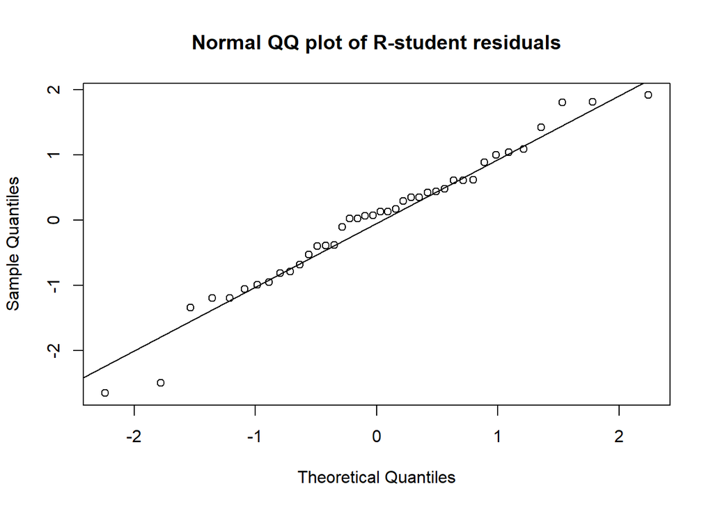

```r
qqnorm(rstudent(model.A),main="Normal QQ plot of R-student residuals")
qqline(rstudent(model.A))
```

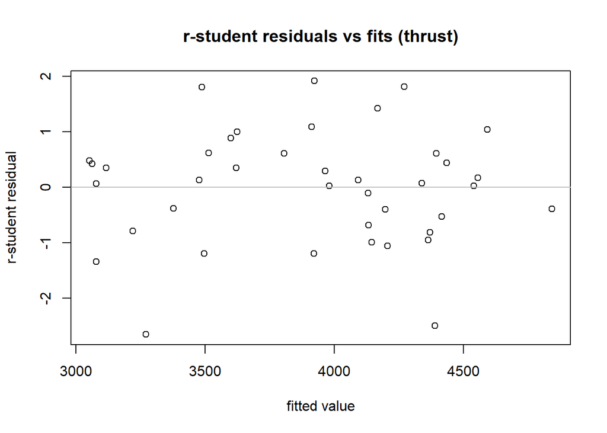

```r
plot(model.A$fitted.values,rstudent(model.A), main="r-student residuals vs fits (thrust)",
     ylab="r-student residual",
     xlab="fitted value")
abline(0, 0, col="gray")
```

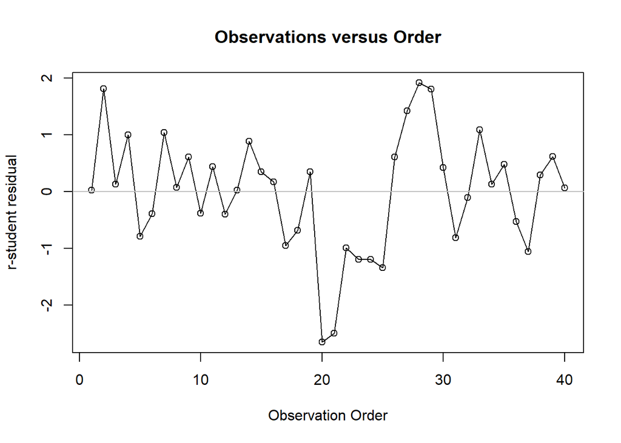

```r
Obs <- seq(1, length(thrust))
plot(Obs, rstudent(model.A),  main = "Observations versus Order", xlab = "Observation Order", ylab = "r-student residual")
lines(Obs, rstudent(model.A))
abline(0, 0, col="gray")
```

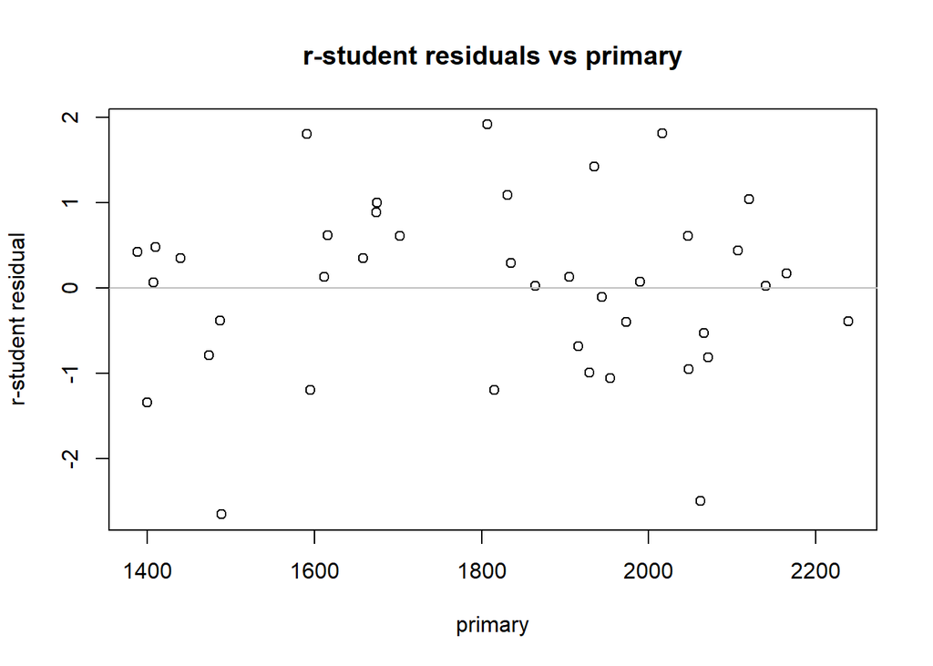

```r
plot(primary,rstudent(model.A), main="r-student residuals vs primary",
     ylab="r-student residual",
     xlab="primary")
abline(0, 0, col="gray")
```

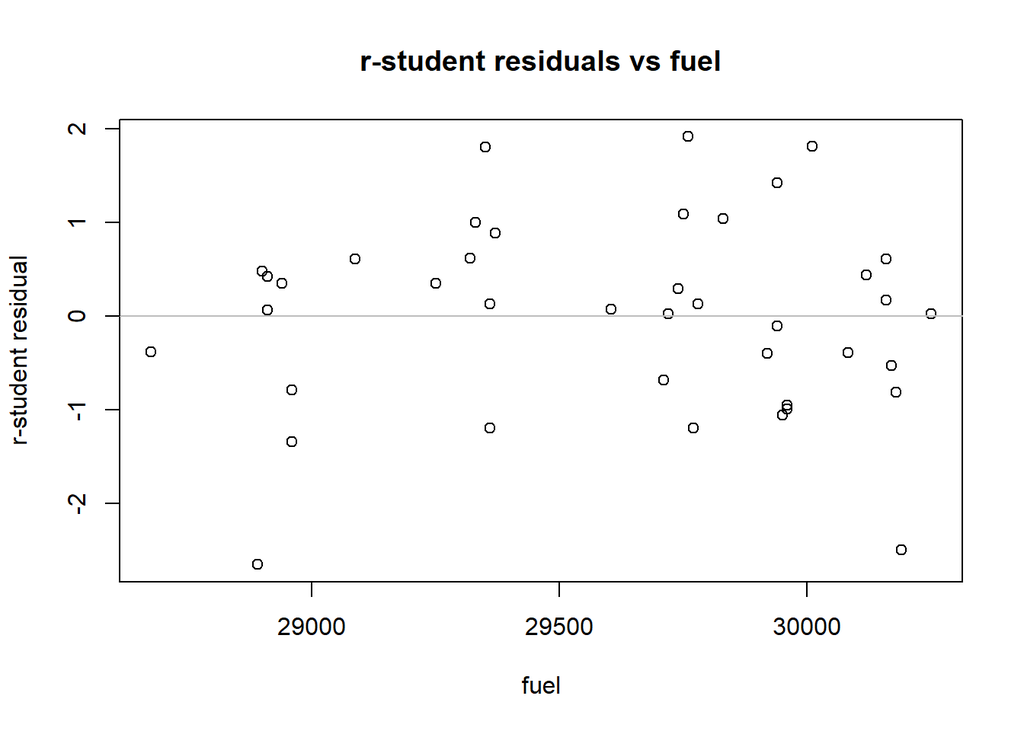

```r
plot(fuel,rstudent(model.A), main="r-student residuals vs fuel",
     ylab="r-student residual",
     xlab="fuel")
abline(0, 0, col="gray")
```

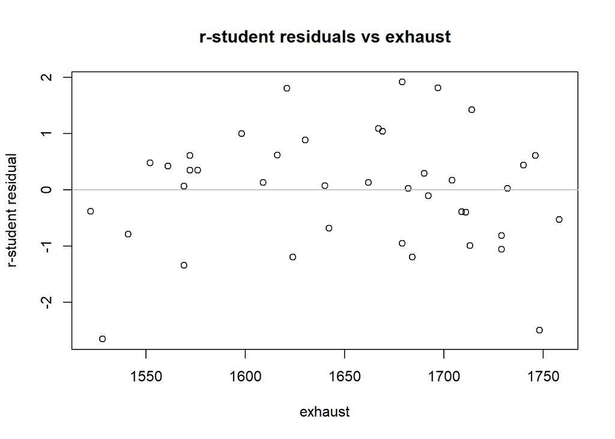

```r
plot(exhaust,rstudent(model.A), main="r-student residuals vs exhaust",
     ylab="r-student residual",
     xlab="exhaust")
abline(0, 0, col="gray")
```

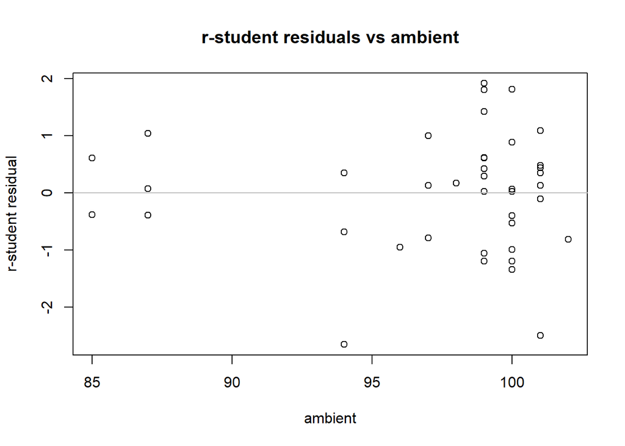

```r
plot(ambient,rstudent(model.A), main="r-student residuals vs ambient",
     ylab="r-student residual",
     xlab="ambient")
abline(0, 0, col="gray")
```

Model A Normality Plot vs residuals – no issues Residuals vs fits – random scatter vs fits – no issues Residuals vs Order – no major issues Residuals vs primary, fuel, exhaust, ambient – good random scatter

#### Influence analysis of model A

```r
# sequence of observations
Obs <- seq(1, length(thrust))

influence_stats <- data.frame(cbind(Obs))

# R-student
r_student <- rstudent(model.A)
influence_stats$r_student <- data.frame(cbind(r_student))

# calculate hat matrix automatically
hat_diags <- lm.influence(model.A)$hat
influence_stats$hat_ii <- data.frame(cbind(hat_diags))

#### this section as a check on observation 14
X <- cbind(matrix(1,length(thrust),1),
           as.matrix(primary),
           as.matrix(fuel),
           as.matrix(exhaust),
           as.matrix(ambient))
y <- as.matrix(thrust)

xTx <- t(X) %*% X
H_matrix <- X %*% ginv(xTx, tol=.Machine$double.eps) %*% t(X)

# get the diagonal
diag(H_matrix)
```

```
##  [1] 0.09851206 0.08720474 0.06310057 0.06244372 0.12583910 0.21502829
##  [7] 0.19133808 0.16895931 0.22948414 0.30650956 0.25157241 0.09978607
## [13] 0.08977048 0.09345752 0.20983836 0.21464388 0.10784381 0.10498505
## [19] 0.12477611 0.13577220 0.08322384 0.07707565 0.08656640 0.11971784
## [25] 0.10126321 0.11850837 0.07954760 0.13631186 0.11737097 0.10209431
## [31] 0.09544737 0.06788580 0.05678206 0.08361876 0.16282205 0.13678220
## [37] 0.13530589 0.07351461 0.04486463 0.14043341
```

```r
#### this section as a check on observation 14

# Cooks D
D_i_auto <- cooks.distance(model.A)
influence_stats$Cooks_D <- c(D_i_auto)

#### as a check on observation 14
# Calculate studentized residuals, r_i (eqn 4.8)
e_i <- model.A$residuals
MS_Res <- anova(model.A)$'Mean Sq'[8]
r_i <- e_i/sqrt(MS_Res * (1-hat_diags))

p <- sum(hat_diags)

D_i <- ((r_i)^2/p) * (hat_diags/(1-hat_diags))

# Calculate DFFITS and DFBETAS
influence_stats$DFFITS <- c(dffits(model.A))
dfbetas.col <- dfbetas(model.A)
influence_stats$DFBETAS_0 <- c(dfbetas.col[,1])
influence_stats$DFBETAS_1 <- c(dfbetas.col[,2])
influence_stats$DFBETAS_2 <- c(dfbetas.col[,3])
influence_stats$DFBETAS_3 <- c(dfbetas.col[,4])
influence_stats$DFBETAS_4 <- c(dfbetas.col[,5])

# Calculate Covariance Ratio
influence_stats$covratio <- c(covratio(model.A))

# Identify observations that exceed limits of 1 +/- 3p/n for COVRATIO
n <- length(thrust)
limit_plus <- (1 + 3*p/n)
limit_minus <- (1 - 3*p/n)
points <- which(influence_stats$covratio > limit_plus | influence_stats$covratio < limit_minus)

# hat matrix cutoff
hm_cutoff <- 2*p/n
pts_hm_cutoff <- which(influence_stats$hat_ii > hm_cutoff)

# Cook's cutoff
Di_cutoff <- 1.0
pts_Di_cutoff <- which(influence_stats$Cooks_D > Di_cutoff)

# DFFITS cutoff
DFFITS_cutoff <- 2 * sqrt(p/n)
pts_DFFITS_cutoff <- which(abs(influence_stats$DFFITS) > DFFITS_cutoff)

# DFBETAS cutoff
DFBETAS_cutoff <- 2/(sqrt(n))

# loop through subset of matrix containing DFBETAS values
count <- 0
pts_DFBETAS_cutoff <- vector() # initialize an empty vector
for (row in 1:n) {
  for (col in 6:10) {

    if (abs(out[row,col]) > DFBETAS_cutoff) {
        count <- count + 1
        pts_DFBETAS_cutoff[count] <- row    # get obs from out matrix
      }
  }
}

if (count > 0) {
  pts_DFBETAS <- unique(pts_DFBETAS_cutoff)
  }
```

Flagged Observations

#### Model B: per video

```r
library(car) # Needed for vif() function

# linear regression model - Model A
model.B <- lm(thrust~primary+fuel+exhaust+ambient+press)
vif(model.B)
```

```
##   primary      fuel   exhaust   ambient     press
## 286.35594 126.48916  32.34355   7.59230 219.44392
```

```r
summary(model.B)
```

```
##
## Call:
## lm(formula = thrust ~ primary + fuel + exhaust + ambient + press)
##
## Residuals:
##     Min      1Q  Median      3Q     Max
## -52.113 -18.321  -0.732  18.010  47.433
##
## Coefficients:
##               Estimate Std. Error t value Pr(>|t|)
## (Intercept) -3982.1058  2236.9356  -1.780 0.083989 .
## primary         1.0964     0.2835   3.867 0.000473 ***
## fuel            0.1843     0.1018   1.810 0.079193 .
## exhaust         0.8343     0.3484   2.394 0.022308 *
## ambient       -16.2781     2.4658  -6.602 1.44e-07 ***
## press           3.7456     2.6681   1.404 0.169432
## ---
## Signif. codes:  0 '***' 0.001 '**' 0.01 '*' 0.05 '.' 0.1 ' ' 1
##
## Residual standard error: 26.36 on 34 degrees of freedom
## Multiple R-squared:  0.9976, Adjusted R-squared:  0.9973
## F-statistic:  2852 on 5 and 34 DF,  p-value: < 2.2e-16
```

```r
anova(model.B)
```

|  | Df | Sum Sq | Mean Sq | F value | Pr(>F) |
| --- | --- | --- | --- | --- | --- |
| primary | 1 | 9833159.525 | 9833159.5248 | 14149.865292 | 3.873765e-46 |
| fuel | 1 | 29183.216 | 29183.2157 | 41.994495 | 2.062293e-07 |
| exhaust | 1 | 4567.425 | 4567.4254 | 6.572501 | 1.494946e-02 |
| ambient | 1 | 40128.663 | 40128.6628 | 57.744937 | 7.905673e-09 |
| press | 1 | 1369.567 | 1369.5666 | 1.970799 | 1.694316e-01 |
| Residuals | 34 | 23627.605 | 694.9296 | NA | NA |

```r
pr <- resid(model.B)/(1 - lm.influence(model.B)$hat)
press_stat <- sum(pr^2)

# Press Statistic
press_stat
```

```
## [1] 34081.58
```

Model B initial review 5 term model – overall significance R^2 a little higher … but, we are using 5 terms Press: 34081

VIF worse than model but better than full model might not need pressure

trade off between rule and pressure.

#### Perform full analysis on Model B

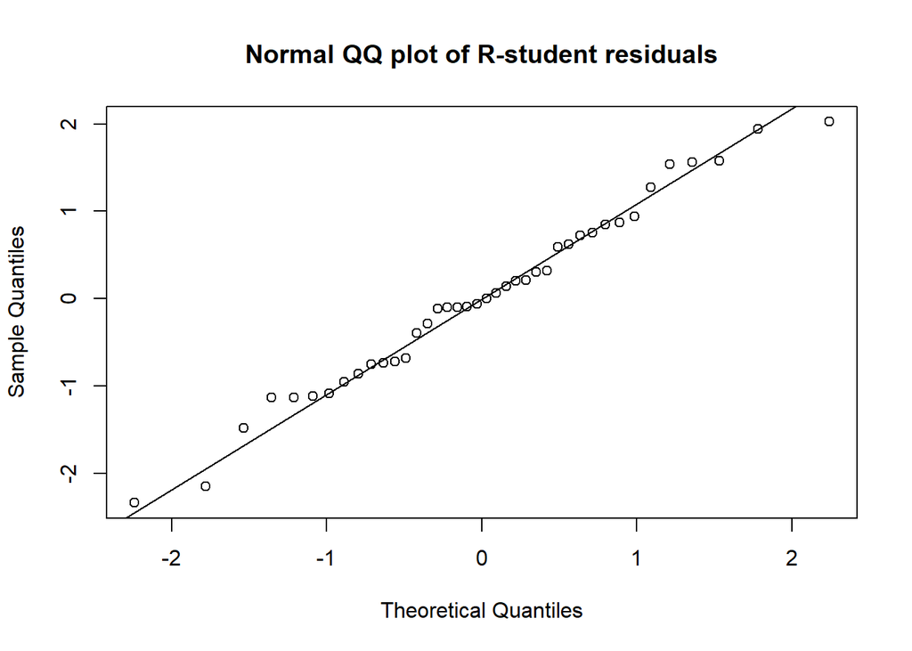

```r
qqnorm(rstudent(model.B),main="Normal QQ plot of R-student residuals")
qqline(rstudent(model.B))
```

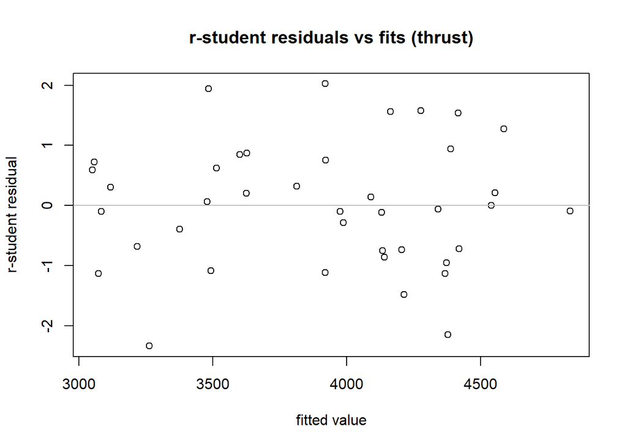

```r
plot(model.B$fitted.values,rstudent(model.B), main="r-student residuals vs fits (thrust)",
     ylab="r-student residual",
     xlab="fitted value")
abline(0, 0, col="gray")
```

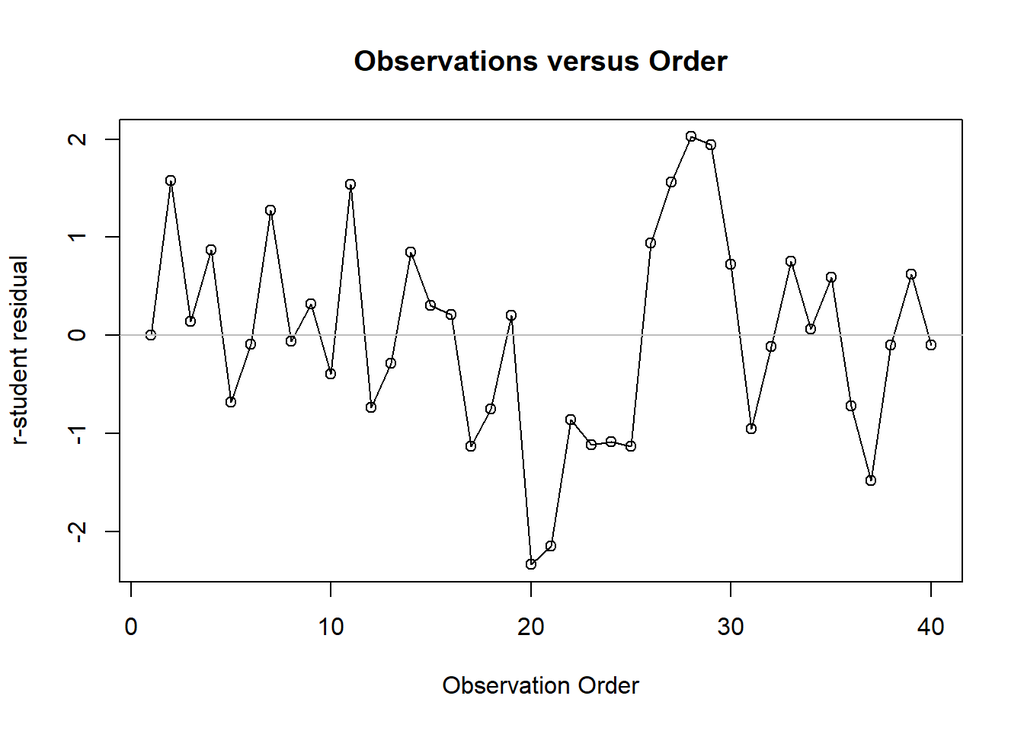

```r
Obs <- seq(1, length(thrust))
plot(Obs, rstudent(model.B),  main = "Observations versus Order", xlab = "Observation Order", ylab = "r-student residual")
lines(Obs, rstudent(model.B))
abline(0, 0, col="gray")
```

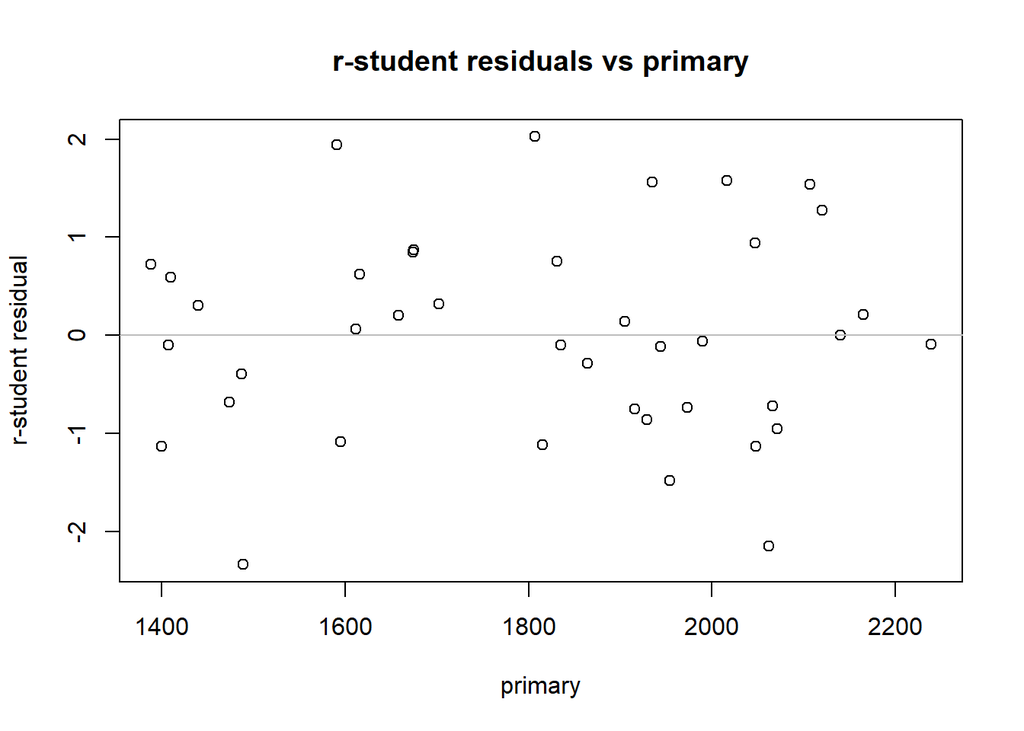

```r
plot(primary,rstudent(model.B), main="r-student residuals vs primary",
     ylab="r-student residual",
     xlab="primary")
abline(0, 0, col="gray")
```

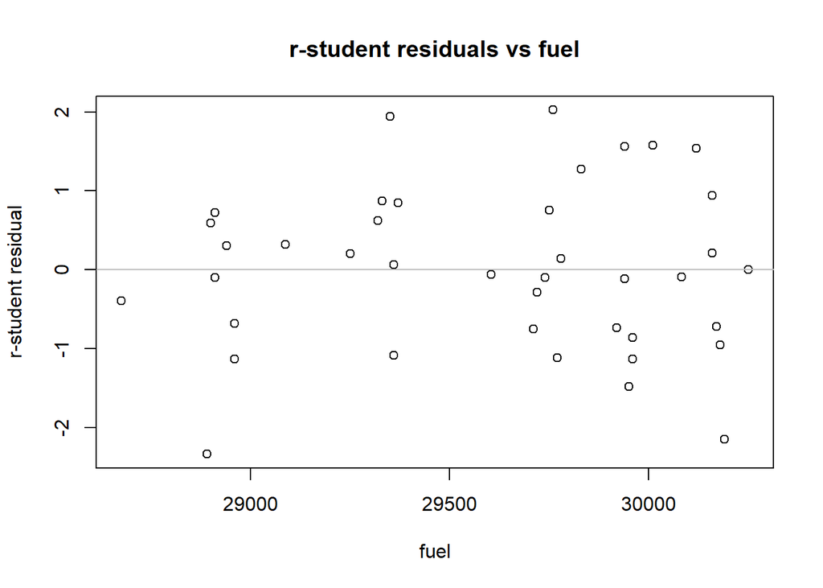

```r
plot(fuel,rstudent(model.B), main="r-student residuals vs fuel",
     ylab="r-student residual",
     xlab="fuel")
abline(0, 0, col="gray")
```

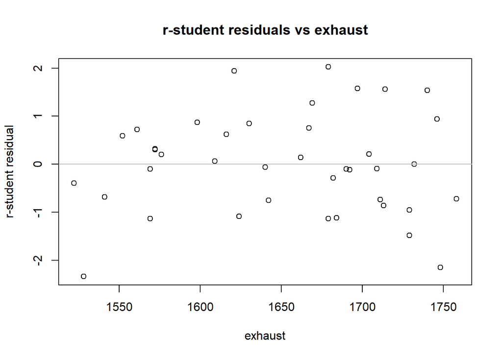

```r
plot(exhaust,rstudent(model.B), main="r-student residuals vs exhaust",
     ylab="r-student residual",
     xlab="exhaust")
abline(0, 0, col="gray")
```

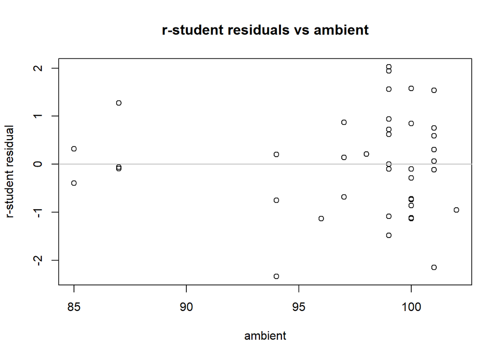

```r
plot(ambient,rstudent(model.B), main="r-student residuals vs ambient",
     ylab="r-student residual",
     xlab="ambient")
abline(0, 0, col="gray")
```

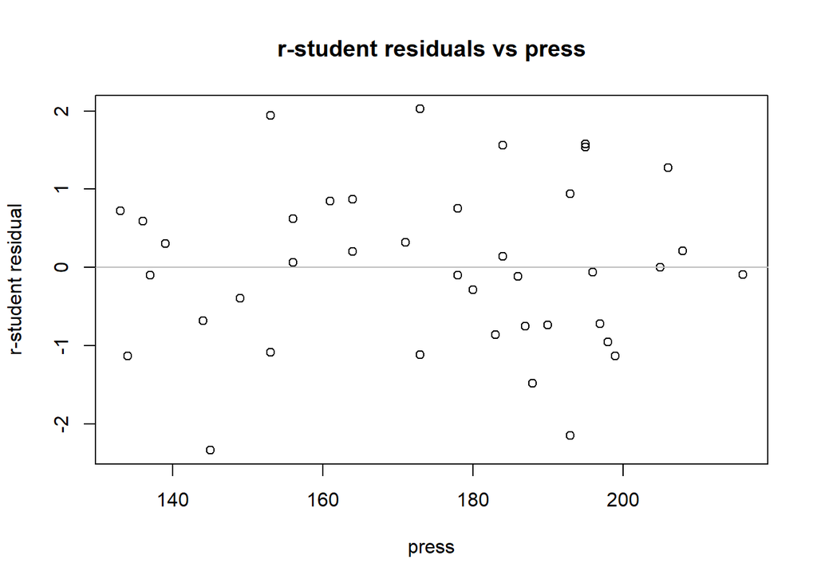

```r
plot(press,rstudent(model.B), main="r-student residuals vs press",
     ylab="r-student residual",
     xlab="press")
abline(0, 0, col="gray")
```

Analysis summary: minor improvements in normality and residual vs fits, regressors

#### Influence analysis of model B

```r
# sequence of observations
Obs <- seq(1, length(thrust))

influence_stats <- data.frame(cbind(Obs))

# R-student
r_student <- rstudent(model.B)
influence_stats$r_student <- data.frame(cbind(r_student))

# calculate hat matrix automatically
hat_diags <- lm.influence(model.B)$hat
influence_stats$hat_ii <- data.frame(cbind(hat_diags))

#### this section as a check on observation 14
X <- cbind(matrix(1,length(thrust),1),
           as.matrix(primary),
           as.matrix(fuel),
           as.matrix(exhaust),
           as.matrix(ambient),
           as.matrix(press))
y <- as.matrix(thrust)

xTx <- t(X) %*% X
H_matrix <- X %*% ginv(xTx, tol=.Machine$double.eps) %*% t(X)

# get the diagonal
diag(H_matrix)
```

```
##  [1] 0.09885473 0.12174357 0.06319091 0.07248289 0.13234159 0.25247271
##  [7] 0.20652084 0.17675472 0.26643787 0.30653319 0.49030000 0.14575268
## [13] 0.13436464 0.09508737 0.21105667 0.21523997 0.11824033 0.10646424
## [19] 0.13533578 0.19192605 0.16081874 0.08720993 0.09067565 0.12753370
## [25] 0.12683926 0.15634179 0.08443508 0.13800374 0.12089448 0.13759532
## [31] 0.10307717 0.06789838 0.12103101 0.08583125 0.16670955 0.15121335
## [37] 0.18667110 0.14804969 0.04490281 0.15316787
```

```r
#### this section as a check on observation 14

# Cooks D
D_i_auto <- cooks.distance(model.B)
influence_stats$Cooks_D <- c(D_i_auto)

#### as a check on observation 14
# Calculate studentized residuals, r_i (eqn 4.8)
e_i <- model.B$residuals
MS_Res <- anova(model.B)$'Mean Sq'[8]
r_i <- e_i/sqrt(MS_Res * (1-hat_diags))

p <- sum(hat_diags)

D_i <- ((r_i)^2/p) * (hat_diags/(1-hat_diags))

# Calculate DFFITS and DFBETAS
influence_stats$DFFITS <- c(dffits(model.B))
dfbetas.col <- dfbetas(model.B)
influence_stats$DFBETAS_0 <- c(dfbetas.col[,1])
influence_stats$DFBETAS_1 <- c(dfbetas.col[,2])
influence_stats$DFBETAS_2 <- c(dfbetas.col[,3])
influence_stats$DFBETAS_3 <- c(dfbetas.col[,4])
influence_stats$DFBETAS_4 <- c(dfbetas.col[,5])
influence_stats$DFBETAS_5 <- c(dfbetas.col[,6])


# Calculate Covariance Ratio
influence_stats$covratio <- c(covratio(model.B))

# Identify observations that exceed limits of 1 +/- 3p/n for COVRATIO
n <- length(thrust)
limit_plus <- (1 + 3*p/n)
limit_minus <- (1 - 3*p/n)
points <- which(influence_stats$covratio > limit_plus | influence_stats$covratio < limit_minus)

# hat matrix cutoff
hm_cutoff <- 2*p/n
pts_hm_cutoff <- which(influence_stats$hat_ii > hm_cutoff)

# Cook's cutoff
Di_cutoff <- 1.0
pts_Di_cutoff <- which(influence_stats$Cooks_D > Di_cutoff)

# DFFITS cutoff
DFFITS_cutoff <- 2 * sqrt(p/n)
pts_DFFITS_cutoff <- which(abs(influence_stats$DFFITS) > DFFITS_cutoff)

# DFBETAS cutoff
DFBETAS_cutoff <- 2/(sqrt(n))

# loop through subset of matrix containing DFBETAS values
count <- 0
pts_DFBETAS_cutoff <- vector() # initialize an empty vector
for (row in 1:n) {
  for (col in 6:11) {

    if (abs(out[row,col]) > DFBETAS_cutoff) {
        count <- count + 1
        pts_DFBETAS_cutoff[count] <- row    # get obs from out matrix
      }
  }
}

if (count > 0) {
  pts_DFBETAS <- unique(pts_DFBETAS_cutoff)
  }
```

Flagged Observations

1. Point(s) $6, 8, 9, 10, 11, 15, 16$ exceed the cutoff $COVRATIO_i$ limits of $1-\frac{3p}{n}=0.55$ and $1+\frac{3p}{n}=1.45$.
2. Point(s) $10, 11$ exceed $h_{ii}$ cutoff of $\frac{2p}{n}=0.3$.
3. Point(s) $$ exceed $D_i$ cutoff of $1$.
4. Point(s) $11, 20, 21, 28$ where $|DFFITS_i|$ exceed cutoff of $2\sqrt{\frac{p}{n}}=0.7745967$.
5. Point(s) $11, 20, 21, 25, 28, 29, 37$ where $|DFBETAS_{j,i}|$ exceed cutoff of $\frac{2}{\sqrt{n}} = 0.3162278$.

Summary Not as well as model A. 4 obs flagged in DFFITS. point 11 has popped up. Model A has done a better job on influence points, however, model B has done a better job in the residual analysis

#### Model C: per video

```r
# linear regression model - Model C
model.C <- lm(thrust~primary+press+exhaust+ambient)
vif(model.C)
```

```
##    primary      press    exhaust    ambient
## 263.589214 212.440398  17.585611   3.477889
```

```r
summary(model.C)
```

```
##
## Call:
## lm(formula = thrust ~ primary + press + exhaust + ambient)
##
## Residuals:
##     Min      1Q  Median      3Q     Max
## -48.116 -16.513  -0.828  14.978  60.854
##
## Coefficients:
##             Estimate Std. Error t value Pr(>|t|)
## (Intercept)  37.6198   273.0182   0.138   0.8912
## primary       1.2411     0.2807   4.421 9.08e-05 ***
## press         4.6082     2.7092   1.701   0.0978 .
## exhaust       1.2603     0.2652   4.753 3.38e-05 ***
## ambient     -12.9932     1.7223  -7.544 7.69e-09 ***
## ---
## Signif. codes:  0 '***' 0.001 '**' 0.01 '*' 0.05 '.' 0.1 ' ' 1
##
## Residual standard error: 27.2 on 35 degrees of freedom
## Multiple R-squared:  0.9974, Adjusted R-squared:  0.9971
## F-statistic:  3346 on 4 and 35 DF,  p-value: < 2.2e-16
```

```r
anova(model.C)
```

|  | Df | Sum Sq | Mean Sq | F value | Pr(>F) |
| --- | --- | --- | --- | --- | --- |
| primary | 1 | 9833159.5248 | 9833159.5248 | 1.328628e+04 | 9.310675e-47 |
| press | 1 | 30783.6204 | 30783.6204 | 4.159394e+01 | 1.985085e-07 |
| exhaust | 1 | 65.8449 | 65.8449 | 8.896772e-02 | 7.672572e-01 |
| ambient | 1 | 42123.5532 | 42123.5532 | 5.691612e+01 | 7.687113e-09 |
| Residuals | 35 | 25903.4567 | 740.0988 | NA | NA |

```r
pr <- resid(model.C)/(1 - lm.influence(model.C)$hat)
press_stat <- sum(pr^2)

# Press Statistic
press_stat
```

```
## [1] 33334.3
```

Model B initial review 5 term model – overall significance R^2 a little higher … but, we are using 5 terms Press: 34081

VIF worse than model but better than full model might not need pressure

trade off between rule and pressure.

#### Perform full analysis on Model C

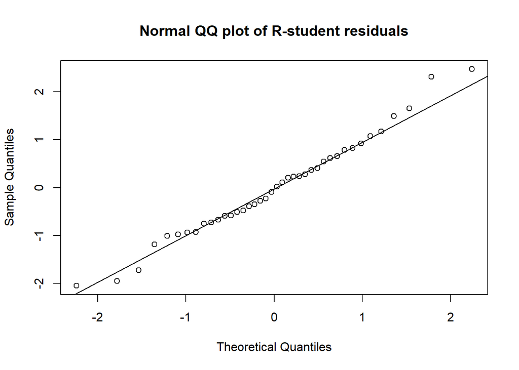

```r
qqnorm(rstudent(model.C),main="Normal QQ plot of R-student residuals")
qqline(rstudent(model.C))
```

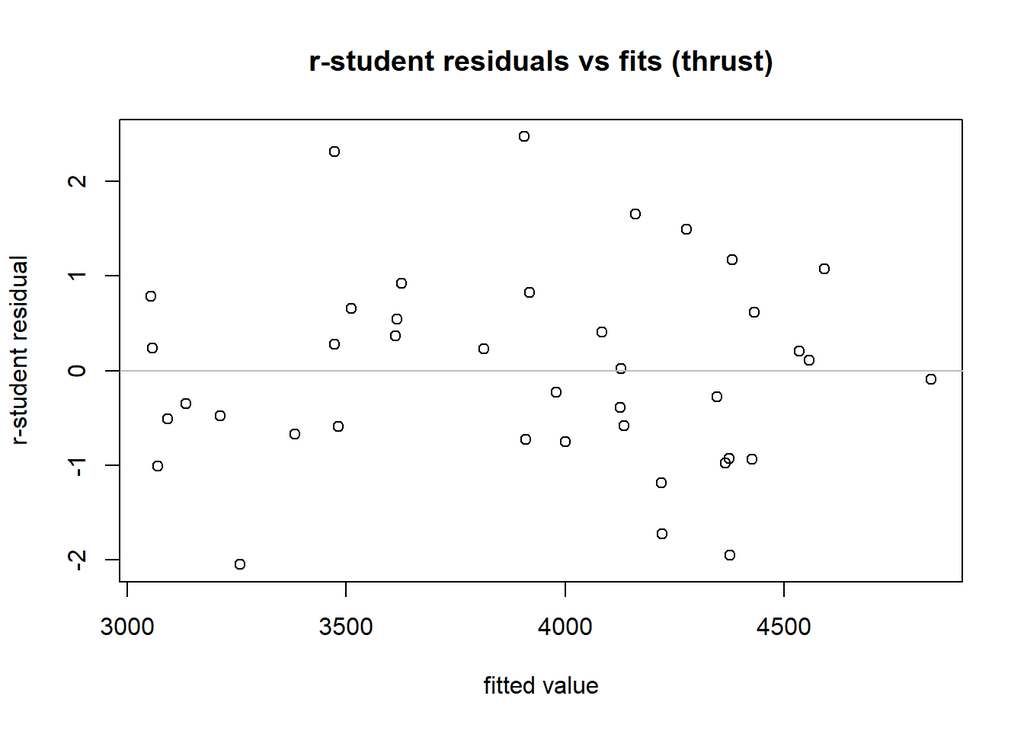

```r
plot(model.C$fitted.values,rstudent(model.C), main="r-student residuals vs fits (thrust)",
     ylab="r-student residual",
     xlab="fitted value")
abline(0, 0, col="gray")
```

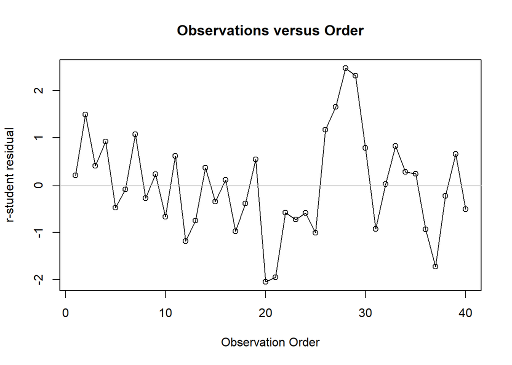

```r
Obs <- seq(1, length(thrust))
plot(Obs, rstudent(model.C),  main = "Observations versus Order", xlab = "Observation Order", ylab = "r-student residual")
lines(Obs, rstudent(model.C))
abline(0, 0, col="gray")
```

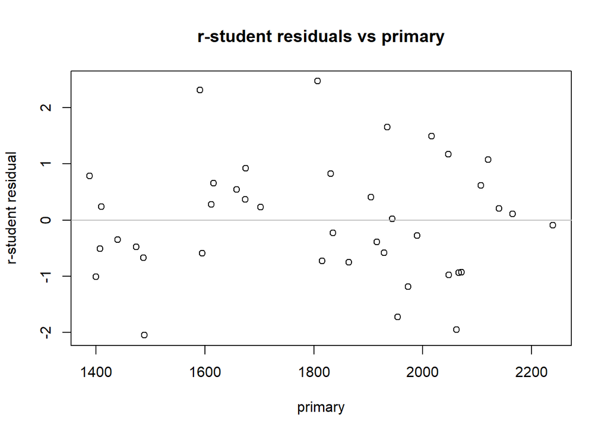

```r
plot(primary,rstudent(model.C), main="r-student residuals vs primary",
     ylab="r-student residual",
     xlab="primary")
abline(0, 0, col="gray")
```

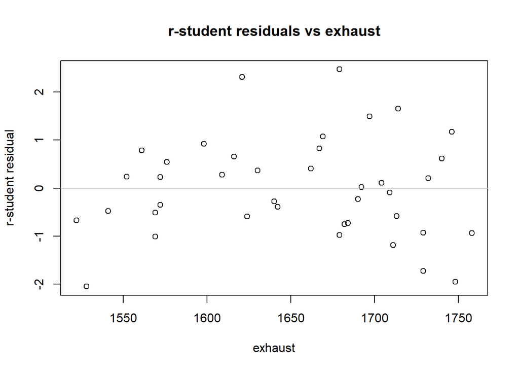

```r
plot(exhaust,rstudent(model.C), main="r-student residuals vs exhaust",
     ylab="r-student residual",
     xlab="exhaust")
abline(0, 0, col="gray")
```

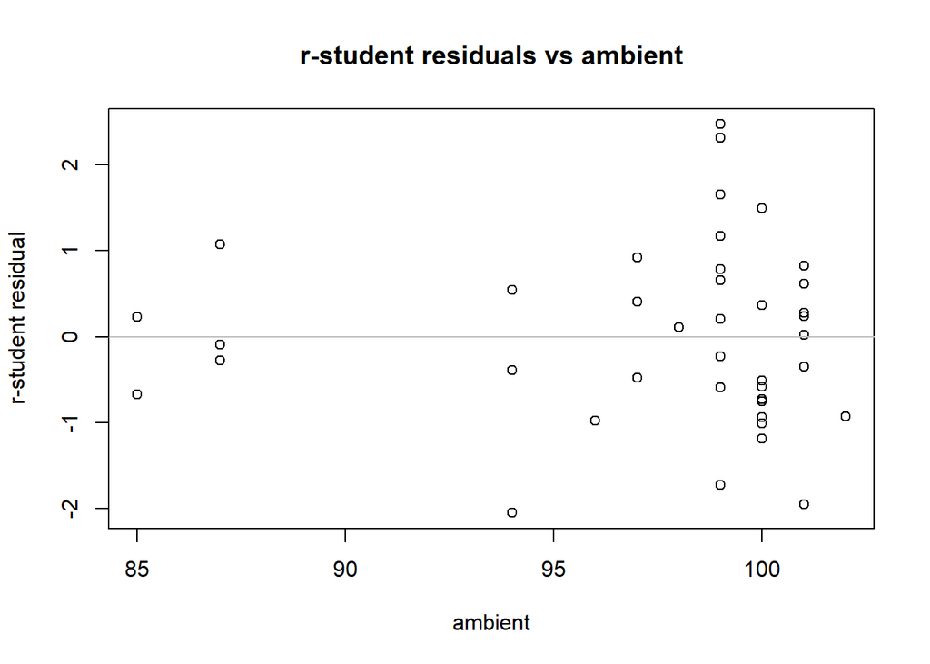

```r
plot(ambient,rstudent(model.C), main="r-student residuals vs ambient",
     ylab="r-student residual",
     xlab="ambient")
abline(0, 0, col="gray")
```

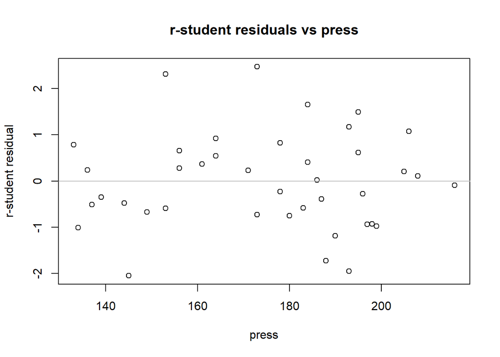

```r
plot(press,rstudent(model.C), main="r-student residuals vs press",
     ylab="r-student residual",
     xlab="press")
abline(0, 0, col="gray")
```

Analysis summary: minor improvements in normality and residual vs fits, regressors

#### Influence analysis of model C

```r
# sequence of observations
Obs <- seq(1, length(thrust))

influence_stats <- data.frame(cbind(Obs))

# R-student
r_student <- rstudent(model.C)
influence_stats$r_student <- data.frame(cbind(r_student))

# calculate hat matrix automatically
hat_diags <- lm.influence(model.C)$hat
influence_stats$hat_ii <- data.frame(cbind(hat_diags))

#### this section as a check on observation 14
X <- cbind(matrix(1,length(thrust),1),
           as.matrix(primary),
           as.matrix(exhaust),
           as.matrix(ambient),
           as.matrix(press))
y <- as.matrix(thrust)

xTx <- t(X) %*% X
H_matrix <- X %*% ginv(xTx, tol=.Machine$double.eps) %*% t(X)

# get the diagonal
diag(H_matrix)
```

```
##  [1] 0.08620745 0.12154395 0.04008740 0.07052370 0.12329572 0.25247271
##  [7] 0.20094042 0.16292634 0.26479315 0.28701912 0.38919734 0.07500691
## [13] 0.06240178 0.03927925 0.09487565 0.21308785 0.11469893 0.07437154
## [19] 0.09931486 0.18490570 0.15794279 0.07013410 0.05748348 0.07381070
## [25] 0.12492490 0.13707559 0.07849526 0.05886297 0.06703799 0.13553688
## [31] 0.10307351 0.06266659 0.11863646 0.07089815 0.13727191 0.13469772
## [37] 0.16471548 0.14322376 0.04395591 0.10260608
```

```r
#### this section as a check on observation 14

# Cooks D
D_i_auto <- cooks.distance(model.C)
influence_stats$Cooks_D <- c(D_i_auto)

#### as a check on observation 14
# Calculate studentized residuals, r_i (eqn 4.8)
e_i <- model.C$residuals
MS_Res <- anova(model.C)$'Mean Sq'[8]
r_i <- e_i/sqrt(MS_Res * (1-hat_diags))

p <- sum(hat_diags)

D_i <- ((r_i)^2/p) * (hat_diags/(1-hat_diags))

# Calculate DFFITS and DFBETAS
influence_stats$DFFITS <- c(dffits(model.C))
dfbetas.col <- dfbetas(model.C)
influence_stats$DFBETAS_0 <- c(dfbetas.col[,1])
influence_stats$DFBETAS_1 <- c(dfbetas.col[,2])
influence_stats$DFBETAS_2 <- c(dfbetas.col[,3])
influence_stats$DFBETAS_3 <- c(dfbetas.col[,4])
influence_stats$DFBETAS_4 <- c(dfbetas.col[,5])

# Calculate Covariance Ratio
influence_stats$covratio <- c(covratio(model.C))

# Identify observations that exceed limits of 1 +/- 3p/n for COVRATIO
n <- length(thrust)
limit_plus <- (1 + 3*p/n)
limit_minus <- (1 - 3*p/n)
points <- which(influence_stats$covratio > limit_plus | influence_stats$covratio < limit_minus)

# hat matrix cutoff
hm_cutoff <- 2*p/n
pts_hm_cutoff <- which(influence_stats$hat_ii > hm_cutoff)

# Cook's cutoff
Di_cutoff <- 1.0
pts_Di_cutoff <- which(influence_stats$Cooks_D > Di_cutoff)

# DFFITS cutoff
DFFITS_cutoff <- 2 * sqrt(p/n)
pts_DFFITS_cutoff <- which(abs(influence_stats$DFFITS) > DFFITS_cutoff)

# DFBETAS cutoff
DFBETAS_cutoff <- 2/(sqrt(n))

# loop through subset of matrix containing DFBETAS values
count <- 0
pts_DFBETAS_cutoff <- vector() # initialize an empty vector
for (row in 1:n) {
  for (col in 6:10) {

    if (abs(out[row,col]) > DFBETAS_cutoff) {
        count <- count + 1
        pts_DFBETAS_cutoff[count] <- row    # get obs from out matrix
      }
  }
}

if (count > 0) {
  pts_DFBETAS <- unique(pts_DFBETAS_cutoff)
  }
```

Flagged Observations

1. Point(s) $6, 9, 10, 11, 16, 28, 29$ exceed the cutoff $COVRATIO_i$ limits of $1-\frac{3p}{n}=0.625$ and $1+\frac{3p}{n}=1.375$.
2. Point(s) $6, 9, 10, 11$ exceed $h_{ii}$ cutoff of $\frac{2p}{n}=0.25$.
3. Point(s) $$ exceed $D_i$ cutoff of $1$.
4. Point(s) $20, 21, 37$ where $|DFFITS_i|$ exceed cutoff of $2\sqrt{\frac{p}{n}}=0.7071068$.
5. Point(s) $11, 20, 21, 25, 28, 29, 37$ where $|DFBETAS_{j,i}|$ exceed cutoff of $\frac{2}{\sqrt{n}} = 0.3162278$.

Summary Multicollinearity exist … as it does in all models A and B. Normal probability plot looks O.K. Residuals vs fits looks good. Model C. shows most leverage points.

```r
library(olsrr)
```

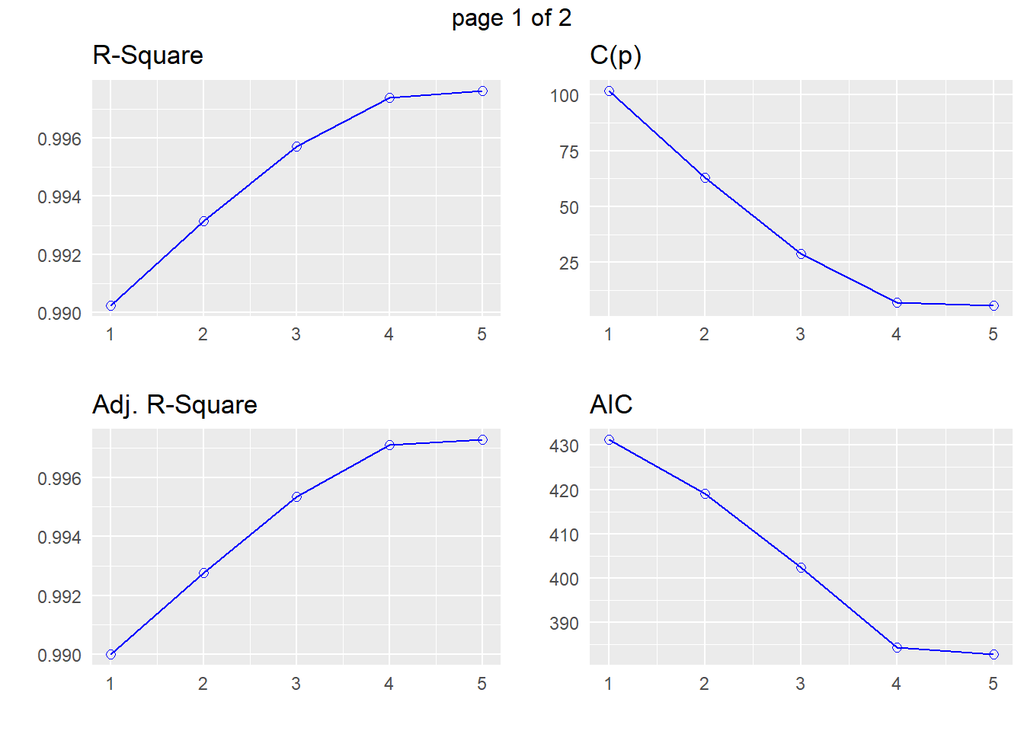

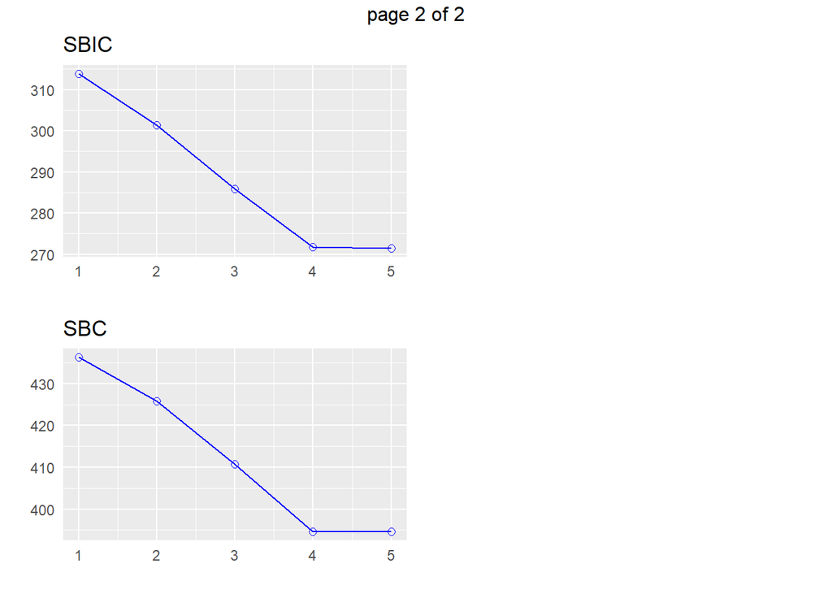

```r
k <- ols_step_forward_p(model, penter=0.1)
plot(k)
```

```r
# final model
k$model
```

```
##
## Call:
## lm(formula = paste(response, "~", paste(preds, collapse = " + ")),
##     data = l)
##
## Coefficients:
## (Intercept)        press      primary      ambient      exhaust         fuel
##  -3982.1058       3.7456       1.0964     -16.2781       0.8343       0.1843
```

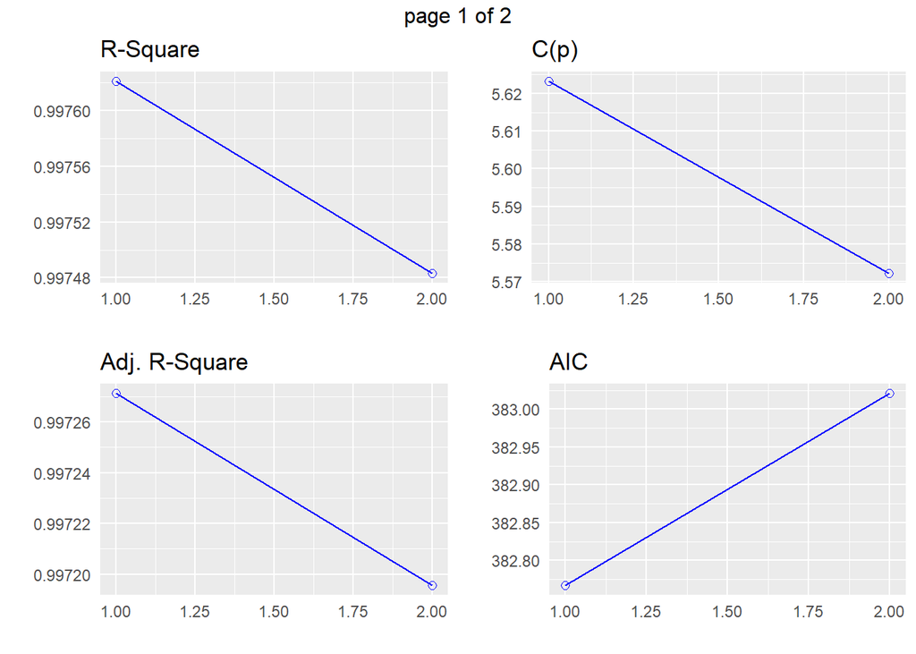

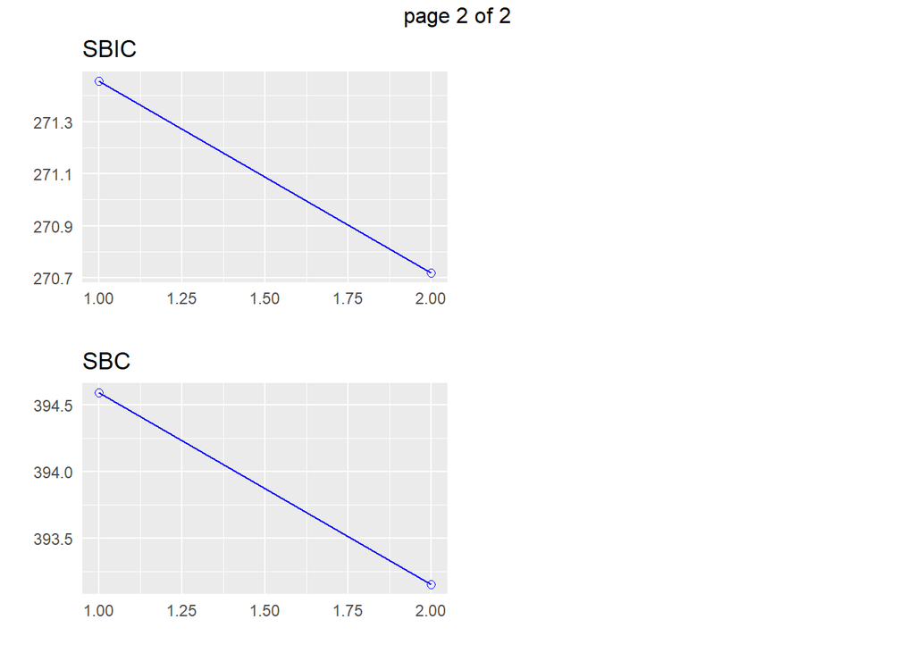

```r
k <- ols_step_backward_p(model, prem =0.1)
plot(k)
```

```r
# final model
k$model
```

```
##
## Call:
## lm(formula = paste(response, "~", paste(preds, collapse = " + ")),
##     data = l)
##
## Coefficients:
## (Intercept)      primary         fuel      exhaust      ambient
##  -4280.1645       1.4420       0.2098       0.6467     -17.5103
```

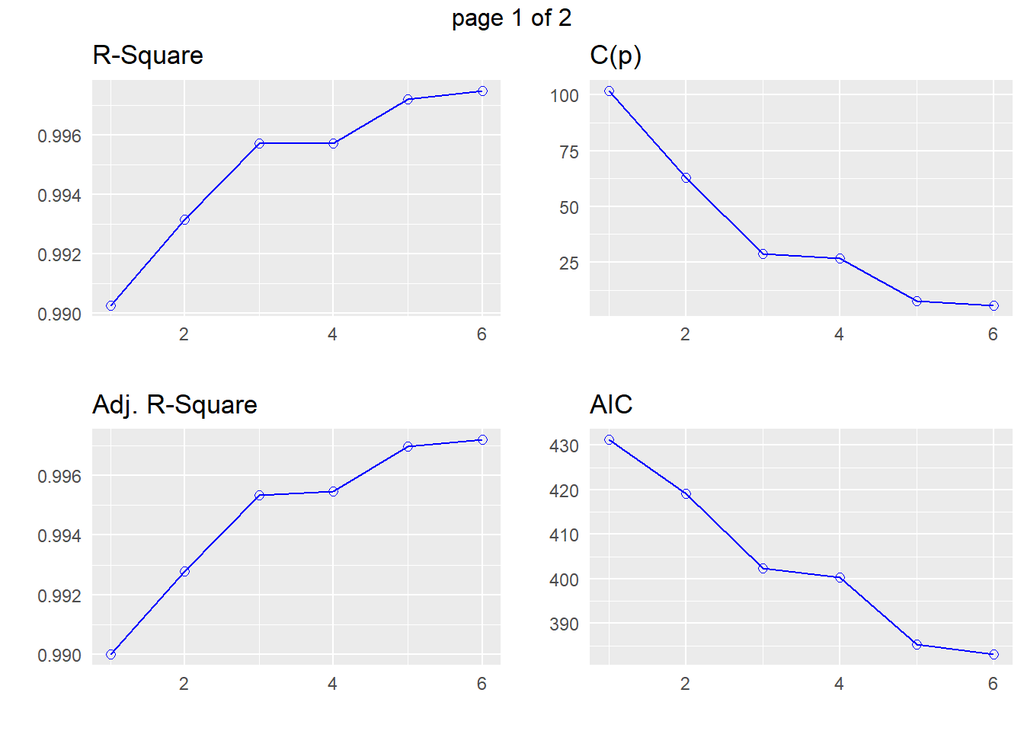

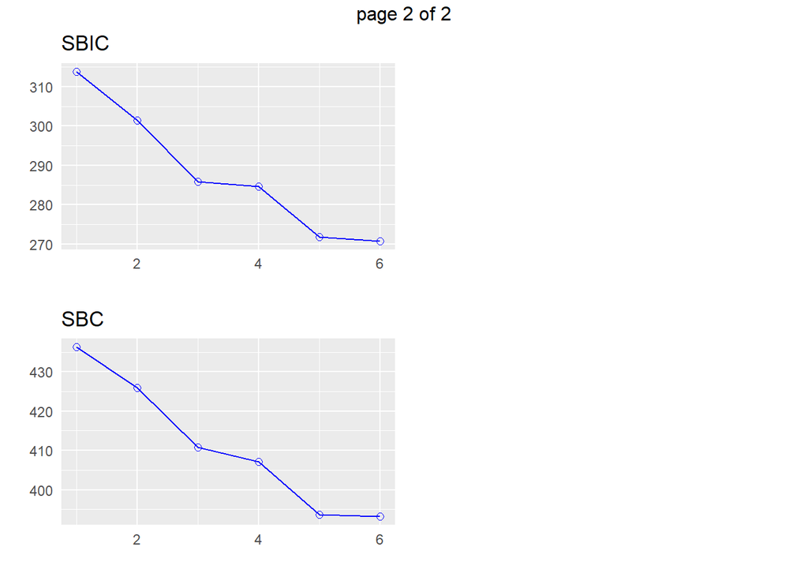

```r
k <- ols_step_both_p(model, prem =0.1)
plot(k)
```

```r
# final model
k$model
```

```
##
## Call:
## lm(formula = paste(response, "~", paste(preds, collapse = " + ")),
##     data = l)
##
## Coefficients:
## (Intercept)      primary      ambient         fuel      exhaust
##  -4280.1645       1.4420     -17.5103       0.2098       0.6467
```